# Opiniones apps Play Store (kaggle) Taller1

Reinier Mujica

1 de marzo de 2019

# 1 Taller1 minería de texto Opiniones de Apps de la Play Store

Se pide:

## 1.1 Carga de datos

En [kaggle](https://www.kaggle.com/lava18/google-play-store-apps) podéis encontrar Dos ficheros cvs que contiene información sobre valoraciones de usuarios de apps de la Play Store y de datos sobre cada app. Descargar y documentar estos datos de Kaggle

```r
library(tidyverse)
library(tidytext)
library(dplyr)
library(stringr)
library(wordcloud)
library(reshape2)
```

```r
metadata_apps=read_csv("googleplaystore.csv")
reviews_apps=read_csv("googleplaystore_user_reviews.csv")
```

Limpiamos un poco los datos

```r
reviews_apps <- reviews_apps %>% filter(Translated_Review!="nan")

# el dataset contiene muchas apps repetidas, por lo que aplico la función distinc,
# segun la web contiene 9660 apps únicas
metadata_apps <-
  metadata_apps %>%
  distinct(App, .keep_all = TRUE) %>%
  filter(Category!="1.9")
```

## 1.2 Análisis descriptivo básico

Realizar un análisis descriptivo básico de las tablas de opiniones y de las a caracterísiticas de las apps

### 1.2.1 Solución

```r
tabla1 <- metadata_apps %>%
  group_by(Category) %>%
  summarise(count=n(),
            Media_Rating=round(mean(Rating,na.rm=TRUE),2),
            Median_Rating=median(Rating,na.rm=TRUE),
            Sd_Rating=sd(Rating,na.rm=TRUE),
            Max_Rating=max(Rating,na.rm=TRUE),
            Min_Rating=min(Rating,na.rm = TRUE))
```

```r
knitr::kable(tabla1)
```

| Category | count | Media_Rating | Median_Rating | Sd_Rating | Max_Rating | Min_Rating |
| --- | --- | --- | --- | --- | --- | --- |
| ART_AND_DESIGN | 64 | 4.36 | 4.4 | 0.3612289 | 5.0 | 3.2 |
| AUTO_AND_VEHICLES | 85 | 4.19 | 4.3 | 0.5436922 | 4.9 | 2.1 |
| BEAUTY | 53 | 4.28 | 4.3 | 0.3626029 | 4.9 | 3.1 |
| BOOKS_AND_REFERENCE | 222 | 4.34 | 4.5 | 0.4376495 | 5.0 | 2.7 |
| BUSINESS | 420 | 4.10 | 4.2 | 0.6598617 | 5.0 | 1.0 |
| COMICS | 56 | 4.18 | 4.4 | 0.5263165 | 5.0 | 2.8 |
| COMMUNICATION | 315 | 4.12 | 4.2 | 0.4702600 | 5.0 | 1.0 |
| DATING | 171 | 3.97 | 4.1 | 0.6377863 | 5.0 | 1.0 |
| EDUCATION | 119 | 4.36 | 4.4 | 0.2636125 | 4.9 | 3.5 |
| ENTERTAINMENT | 102 | 4.14 | 4.2 | 0.3284066 | 4.7 | 3.0 |
| EVENTS | 64 | 4.44 | 4.5 | 0.4194995 | 5.0 | 2.9 |
| FAMILY | 1832 | 4.18 | 4.3 | 0.5233235 | 5.0 | 1.0 |
| FINANCE | 345 | 4.12 | 4.3 | 0.6591469 | 5.0 | 1.0 |
| FOOD_AND_DRINK | 112 | 4.17 | 4.3 | 0.5669015 | 5.0 | 1.7 |
| GAME | 959 | 4.25 | 4.3 | 0.3841161 | 5.0 | 1.0 |
| HEALTH_AND_FITNESS | 288 | 4.24 | 4.5 | 0.6688180 | 5.0 | 1.4 |
| HOUSE_AND_HOME | 74 | 4.15 | 4.2 | 0.3797108 | 4.8 | 2.8 |
| LIBRARIES_AND_DEMO | 84 | 4.18 | 4.2 | 0.3815044 | 5.0 | 3.1 |
| LIFESTYLE | 369 | 4.09 | 4.2 | 0.7049509 | 5.0 | 1.5 |
| MAPS_AND_NAVIGATION | 131 | 4.04 | 4.2 | 0.5273163 | 4.9 | 1.9 |
| MEDICAL | 395 | 4.17 | 4.3 | 0.6909838 | 5.0 | 1.0 |
| NEWS_AND_MAGAZINES | 254 | 4.12 | 4.2 | 0.5665777 | 5.0 | 1.7 |
| PARENTING | 60 | 4.30 | 4.4 | 0.5178448 | 5.0 | 2.0 |
| PERSONALIZATION | 376 | 4.33 | 4.4 | 0.3589676 | 5.0 | 2.5 |
| PHOTOGRAPHY | 281 | 4.16 | 4.3 | 0.4943306 | 5.0 | 2.0 |
| PRODUCTIVITY | 374 | 4.18 | 4.3 | 0.5342813 | 5.0 | 1.0 |
| SHOPPING | 202 | 4.23 | 4.3 | 0.4451978 | 5.0 | 1.6 |
| SOCIAL | 239 | 4.25 | 4.3 | 0.4572085 | 5.0 | 1.9 |
| SPORTS | 325 | 4.22 | 4.3 | 0.4626270 | 5.0 | 1.5 |
| TOOLS | 827 | 4.04 | 4.2 | 0.6202720 | 5.0 | 1.0 |
| TRAVEL_AND_LOCAL | 219 | 4.07 | 4.2 | 0.5320697 | 5.0 | 2.2 |
| VIDEO_PLAYERS | 163 | 4.04 | 4.2 | 0.5637923 | 4.9 | 1.8 |
| WEATHER | 79 | 4.24 | 4.3 | 0.3376916 | 4.8 | 3.3 |

Top 10 de Apps con mas reseñas

```r
top10_apps_reviews <-
  reviews_apps %>%
  group_by(App) %>%
  summarise(N=n()) %>%
  arrange(desc(N)) %>%
  top_n(10)

knitr::kable(top10_apps_reviews)
```

| App | N |
| --- | --- |
| Bowmasters | 312 |
| Angry Birds Classic | 273 |
| Helix Jump | 273 |
| Calorie Counter - MyFitnessPal | 254 |
| Candy Crush Saga | 240 |
| Duolingo: Learn Languages Free | 240 |
| Garena Free Fire | 222 |
| 8 Ball Pool | 219 |
| Calorie Counter - Macros | 200 |
| 10 Best Foods for You | 194 |

Top 10 de Categorias con mas reseñas

```r
top10_cat_reviews <-
  reviews_apps %>%
  group_by(App) %>%
  summarise(reviews_count=n()) %>%
  inner_join(metadata_apps) %>%
  ungroup() %>%
  group_by(Category) %>%
  summarise(reviews_cat = sum(reviews_count)) %>%
  arrange(desc(reviews_cat)) %>%
  top_n(10)

knitr::kable(top10_cat_reviews)
```

| Category | reviews_cat |
| --- | --- |
| GAME | 6678 |
| HEALTH_AND_FITNESS | 2249 |
| FAMILY | 2009 |
| DATING | 1715 |
| TRAVEL_AND_LOCAL | 1692 |
| SPORTS | 1479 |
| PRODUCTIVITY | 1463 |
| TOOLS | 1451 |
| FINANCE | 1435 |
| MEDICAL | 1400 |

## 1.3 Análisis de sentimiento

Utilizar los tres diccionarios que hemos visto para análisis de sentimiento y comparar con las calificaciones de los reviews que se dan en kaggle

### 1.3.1 Separamos las palabras de cada reviews y las reviews para cada App

```r
tidy_reviews <-
  reviews_apps %>%
  mutate(Review_num = row_number()) %>%
  unnest_tokens(word, Translated_Review)

apps_review <-
  reviews_apps %>%
  transmute(Review_num = row_number(), App = App)
```

### 1.3.2 Usando AFINN

Agregamos una columna con el score de AFINN

```r
reviews_sentiments <-
  tidy_reviews %>%
  inner_join(get_sentiments("afinn")) %>%
  mutate(affin_score = score, score = NULL)

knitr::kable(head(reviews_sentiments))
```

| App | Sentiment | Sentiment_Polarity | Sentiment_Subjectivity | Review_num | word | affin_score |
| --- | --- | --- | --- | --- | --- | --- |
| 10 Best Foods for You | Positive | 1.00 | 0.5333333 | 1 | like | 2 |
| 10 Best Foods for You | Positive | 1.00 | 0.5333333 | 1 | best | 3 |
| 10 Best Foods for You | Positive | 1.00 | 0.5333333 | 1 | helps | 2 |
| 10 Best Foods for You | Positive | 1.00 | 0.5333333 | 1 | best | 3 |
| 10 Best Foods for You | Positive | 0.25 | 0.2884615 | 2 | help | 2 |
| 10 Best Foods for You | Positive | 0.25 | 0.2884615 | 2 | healthy | 2 |

Calculamos la suma de los scores de AFINN de las review

```r
afinn <-
  reviews_sentiments %>%
  group_by(Review_num) %>%
  summarise(score_sum = sum(affin_score)) %>%
  inner_join(apps_review)

afinn_all_apps <-
  reviews_sentiments %>%
  group_by(App) %>%
  summarise(score_sum = sum(affin_score)) %>%
  mutate(method="AFINN")
```

Gráficamos los scores de las 10 Apps con más reviews

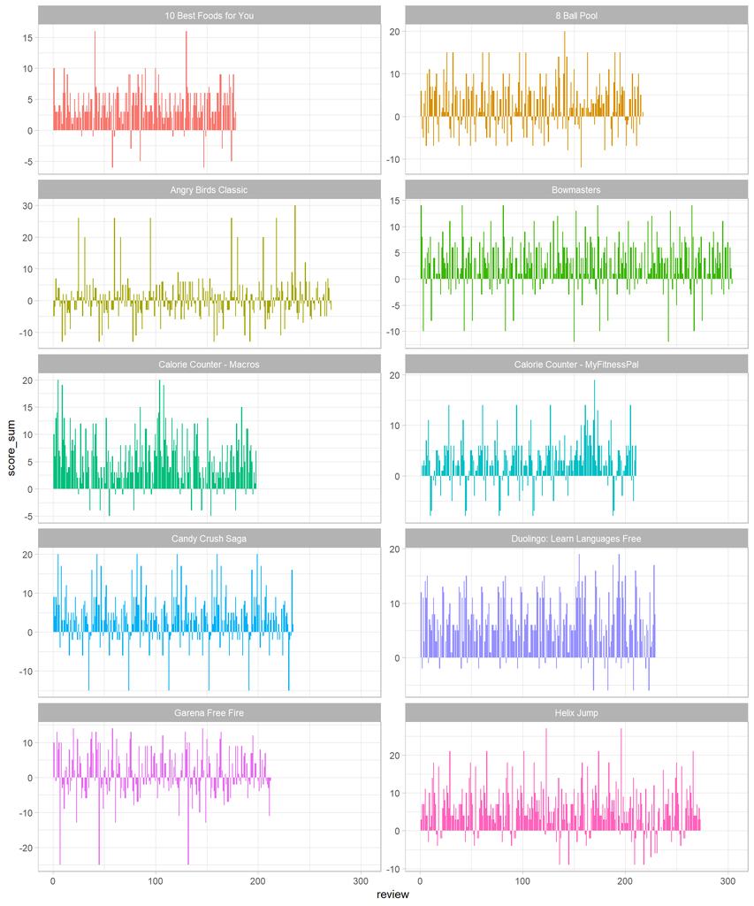

### 1.3.3 Usando BING

Agregamos una columna con el score de BING

```r
reviews_sentiments <-
  tidy_reviews %>%
  inner_join(get_sentiments("bing")) %>%
  mutate(bing_score = sentiment, sentiment = NULL)

knitr::kable(head(reviews_sentiments))
```

| App | Sentiment | Sentiment_Polarity | Sentiment_Subjectivity | Review_num | word | bing_score |
| --- | --- | --- | --- | --- | --- | --- |
| 10 Best Foods for You | Positive | 1.00 | 0.5333333 | 1 | like | positive |
| 10 Best Foods for You | Positive | 1.00 | 0.5333333 | 1 | delicious | positive |
| 10 Best Foods for You | Positive | 1.00 | 0.5333333 | 1 | best | positive |
| 10 Best Foods for You | Positive | 1.00 | 0.5333333 | 1 | best | positive |
| 10 Best Foods for You | Positive | 0.25 | 0.2884615 | 2 | healthy | positive |
| 10 Best Foods for You | Positive | 0.40 | 0.8750000 | 3 | works | positive |

Calculamos la diferencia entre positivos y negativos de las review

```r
bing <-
  reviews_sentiments %>%
  group_by(Review_num) %>%
  count(App, index = row_number(), bing_score) %>%
  spread(bing_score, n, fill = 0) %>%
  mutate(bing_score2 = positive - negative) %>%
  summarise(score_sum = sum(bing_score2)) %>%
  inner_join(apps_review)

bing_all_apps <-
  reviews_sentiments %>%
  group_by(App) %>%
  count(App, index = row_number(), bing_score) %>%
  spread(bing_score, n, fill = 0) %>%
  mutate(bing_score2 = positive - negative) %>%
  summarise(score_sum = sum(bing_score2)) %>%
  mutate(method="BING")
```

Gráficamos los scores de las 10 Apps con más reviews

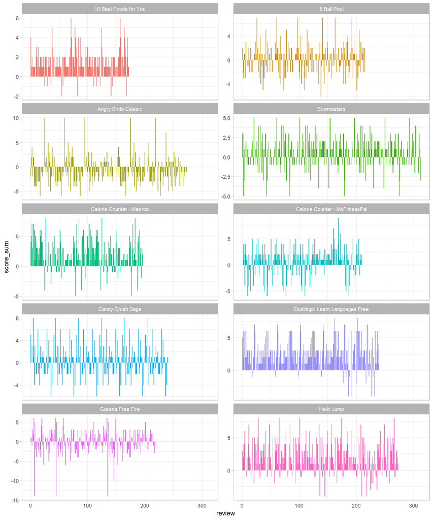

### 1.3.4 Usando NRC

Agregamos una columna con el score de NRC

```r
reviews_sentiments <-
  tidy_reviews %>%
  inner_join(get_sentiments("nrc") %>% filter(sentiment %in% c("positive", "negative"))) %>%
  mutate(nrc_score = sentiment, sentiment = NULL)

knitr::kable(head(reviews_sentiments))
```

| App | Sentiment | Sentiment_Polarity | Sentiment_Subjectivity | Review_num | word | nrc_score |
| --- | --- | --- | --- | --- | --- | --- |
| 10 Best Foods for You | Positive | 1.00 | 0.5333333 | 1 | eat | positive |
| 10 Best Foods for You | Positive | 1.00 | 0.5333333 | 1 | delicious | positive |
| 10 Best Foods for You | Positive | 1.00 | 0.5333333 | 1 | food | positive |
| 10 Best Foods for You | Positive | 1.00 | 0.5333333 | 1 | food | positive |
| 10 Best Foods for You | Positive | 1.00 | 0.5333333 | 1 | case | negative |
| 10 Best Foods for You | Positive | 0.25 | 0.2884615 | 2 | healthy | positive |

Calculamos la diferencia entre positivos y negativos de las review, similar a bing, solo filtramos los sentimientos de nrc para quedarnos con solo dos

```r
nrc <-
  reviews_sentiments %>%
  group_by(Review_num) %>%
  count(App, index = row_number(), nrc_score) %>%
  spread(nrc_score, n, fill = 0) %>%
  mutate(nrc_score2 = positive - negative) %>%
  summarise(score_sum = sum(nrc_score2)) %>%
  inner_join(apps_review)

nrc_all_apps <-
  reviews_sentiments %>%
  group_by(App) %>%
  count(App, index = row_number(), nrc_score) %>%
  spread(nrc_score, n, fill = 0) %>%
  mutate(nrc_score2 = positive - negative) %>%
  summarise(score_sum = sum(nrc_score2)) %>%
  mutate(method="NRC")
```

Gráficamos los scores de las 10 Apps con más reviews

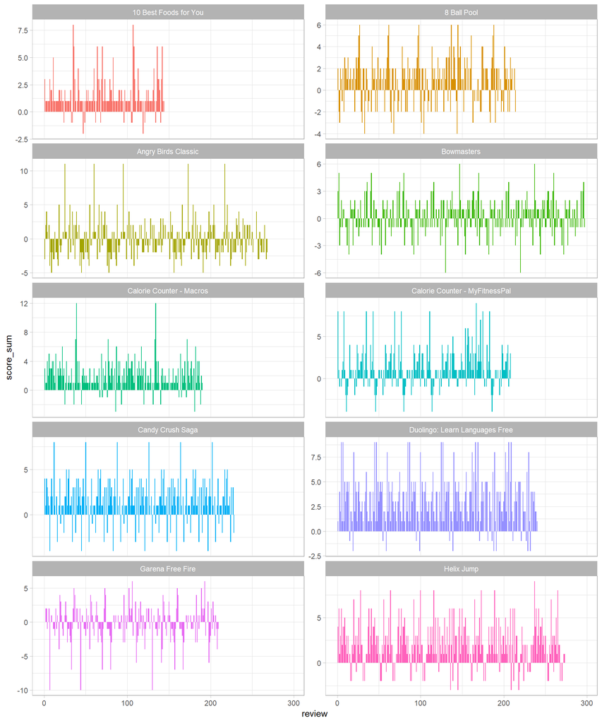

## 1.4 Comparando los tres diccionarios

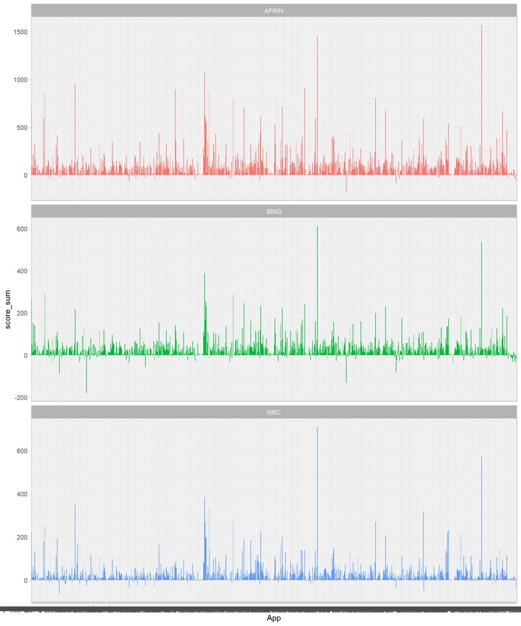

Como se puede observar los resultados son similares

## 1.5 Calcular las tf-idf

Para cada tipo de aplicación calcular las tf-idf y comparar las palabaras más usadas

Haremos un un dataframe tidy con las reviews, la app, y la categoria de la app en una misma row.

```r
app_categories <-
  metadata_apps %>%
  group_by(Category) %>%
  transmute(App = App)

tidy_rev_cat <-
  tidy_reviews %>%
  inner_join(app_categories)

knitr::kable(head(tidy_rev_cat))
```

| App | Sentiment | Sentiment_Polarity | Sentiment_Subjectivity | Review_num | word | Category |
| --- | --- | --- | --- | --- | --- | --- |
| 10 Best Foods for You | Positive | 1 | 0.5333333 | 1 | i | HEALTH_AND_FITNESS |
| 10 Best Foods for You | Positive | 1 | 0.5333333 | 1 | like | HEALTH_AND_FITNESS |
| 10 Best Foods for You | Positive | 1 | 0.5333333 | 1 | eat | HEALTH_AND_FITNESS |
| 10 Best Foods for You | Positive | 1 | 0.5333333 | 1 | delicious | HEALTH_AND_FITNESS |
| 10 Best Foods for You | Positive | 1 | 0.5333333 | 1 | food | HEALTH_AND_FITNESS |
| 10 Best Foods for You | Positive | 1 | 0.5333333 | 1 | that’s | HEALTH_AND_FITNESS |

Ahora procedemos a remover las stopwords de las reviews

```r
tidy_rev_cat <-
  tidy_rev_cat %>%
  anti_join(stop_words, by = c("word" = "word"))

knitr::kable(head(tidy_rev_cat))
```

| App | Sentiment | Sentiment_Polarity | Sentiment_Subjectivity | Review_num | word | Category |
| --- | --- | --- | --- | --- | --- | --- |
| 10 Best Foods for You | Positive | 1 | 0.5333333 | 1 | eat | HEALTH_AND_FITNESS |
| 10 Best Foods for You | Positive | 1 | 0.5333333 | 1 | delicious | HEALTH_AND_FITNESS |
| 10 Best Foods for You | Positive | 1 | 0.5333333 | 1 | food | HEALTH_AND_FITNESS |
| 10 Best Foods for You | Positive | 1 | 0.5333333 | 1 | cooking | HEALTH_AND_FITNESS |
| 10 Best Foods for You | Positive | 1 | 0.5333333 | 1 | food | HEALTH_AND_FITNESS |
| 10 Best Foods for You | Positive | 1 | 0.5333333 | 1 | 10 | HEALTH_AND_FITNESS |

Calcularemos la cantidad total de términos y la frecuencia de cada uno, agrupando por categoria las apps

```r
cat_words <-
  tidy_rev_cat %>%
  count(Category, word, sort = TRUE) %>%
  ungroup()

total_words <- cat_words %>%
  group_by(Category) %>%
  summarize(total = sum(n))

all_words <- left_join(cat_words, total_words)
```

Ahora mostraremos un gráfico de las 10 categorias con mas reviews y su distribución de la frecuencia de términos

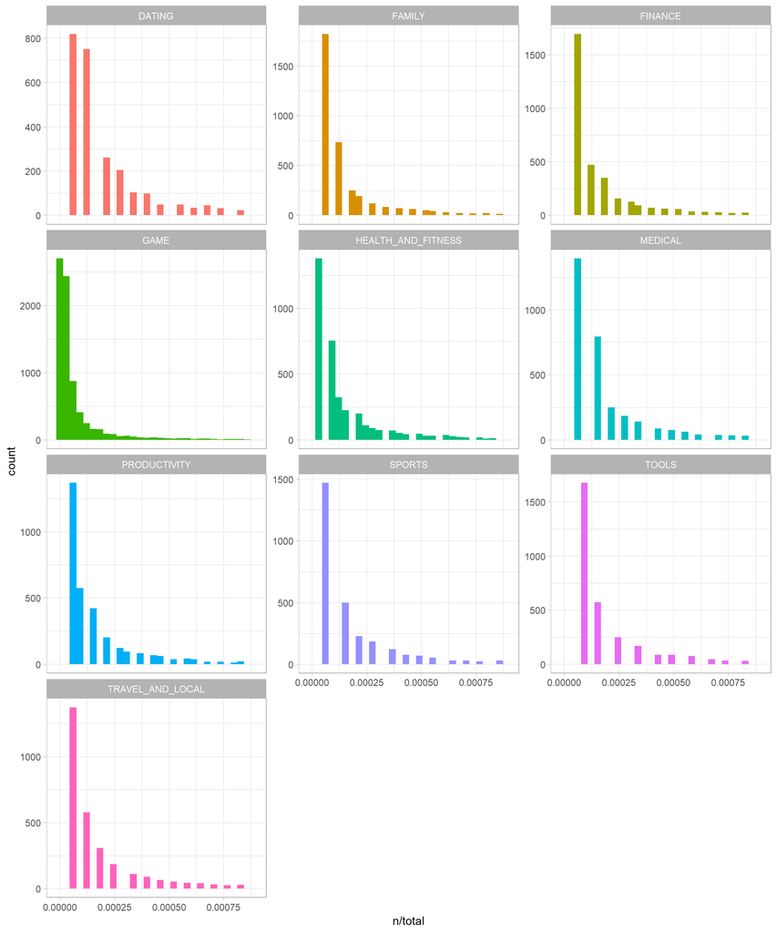

Ahora procedemos a calcular la tf y idf.

```r
tfidf_words <- all_words %>%
  bind_tf_idf(word, Category, n) %>%
  arrange(desc(tf_idf))

knitr::kable(tfidf_words %>% filter(Category %in% top10_cat_reviews$Category) %>% top_n(20))
```

| Category | word | n | total | tf | idf | tf_idf |
| --- | --- | --- | --- | --- | --- | --- |
| DATING | dating | 306 | 14746 | 0.0207514 | 2.3978953 | 0.0497597 |
| GAME | game | 7464 | 97115 | 0.0768573 | 0.2776317 | 0.0213380 |
| FAMILY | game | 1305 | 17643 | 0.0739670 | 0.2776317 | 0.0205356 |
| TRAVEL_AND_LOCAL | flights | 87 | 15472 | 0.0056231 | 3.4965076 | 0.0196611 |
| TRAVEL_AND_LOCAL | booking | 158 | 15472 | 0.0102120 | 1.8870696 | 0.0192707 |
| HEALTH_AND_FITNESS | calories | 192 | 24999 | 0.0076803 | 2.3978953 | 0.0184166 |
| TRAVEL_AND_LOCAL | hotels | 98 | 15472 | 0.0063340 | 2.8033604 | 0.0177565 |
| TRAVEL_AND_LOCAL | hotel | 177 | 15472 | 0.0114400 | 1.5505974 | 0.0177389 |
| TRAVEL_AND_LOCAL | flight | 149 | 15472 | 0.0096303 | 1.5505974 | 0.0149327 |
| PRODUCTIVITY | notes | 273 | 19133 | 0.0142685 | 1.0116009 | 0.0144341 |
| HEALTH_AND_FITNESS | macros | 128 | 24999 | 0.0051202 | 2.8033604 | 0.0143538 |
| SPORTS | golf | 69 | 14171 | 0.0048691 | 2.8033604 | 0.0136498 |
| SPORTS | sports | 156 | 14171 | 0.0110084 | 1.1939225 | 0.0131432 |
| HEALTH_AND_FITNESS | workout | 116 | 24999 | 0.0046402 | 2.8033604 | 0.0130081 |
| HEALTH_AND_FITNESS | workouts | 112 | 24999 | 0.0044802 | 2.8033604 | 0.0125596 |
| HEALTH_AND_FITNESS | food | 334 | 24999 | 0.0133605 | 0.9315582 | 0.0124461 |
| HEALTH_AND_FITNESS | weight | 177 | 24999 | 0.0070803 | 1.7047481 | 0.0120701 |
| FINANCE | bank | 179 | 17129 | 0.0104501 | 1.0116009 | 0.0105713 |
| TOOLS | alarm | 96 | 11982 | 0.0080120 | 1.2992830 | 0.0104099 |
| MEDICAL | doctor | 70 | 14388 | 0.0048652 | 2.1102132 | 0.0102665 |

Visualizaremos de las 10 categorias de Apps con mas reviews sus 15 primeros terminos con mayor valor de tf_idf

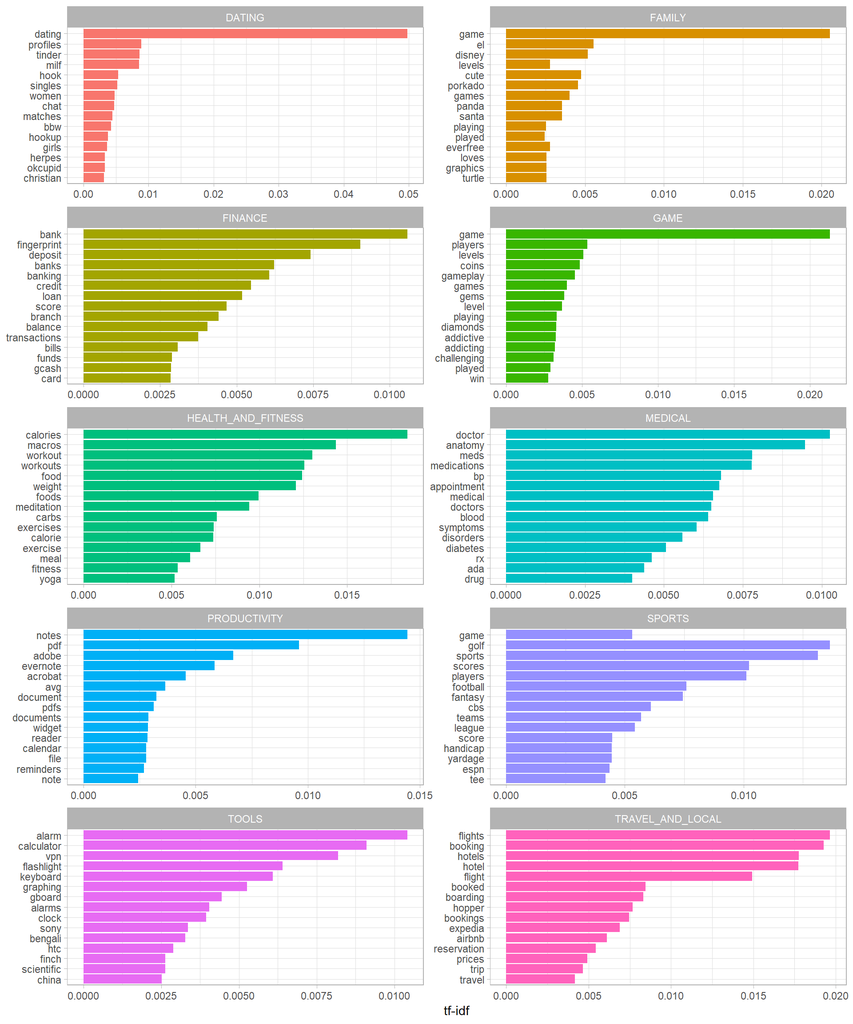

Ahora mostraremos los 10 terminos mas usados de las 10 reviews mas positivas de las apps con mas reviews, usaremos los resultados anteriores de AFINN como referencia

```r
top10_best_reviews <- afinn %>%
  filter(App %in% top10_apps_reviews$App) %>%
  group_by(App) %>%
  arrange(desc(score_sum)) %>%
  filter(row_number() <= 10)

best_words <- top10_best_reviews %>%
  inner_join(tidy_reviews %>% mutate(App = NULL)) %>%
  inner_join(app_categories) %>%
  inner_join(tfidf_words, by=c("word", "Category")) %>%
  group_by(App) %>%
  distinct(word, .keep_all = TRUE) %>%
  ungroup() %>%
  arrange(App, desc(tf_idf)) %>%
  group_by(App) %>%
  filter(row_number() <= 10)
```

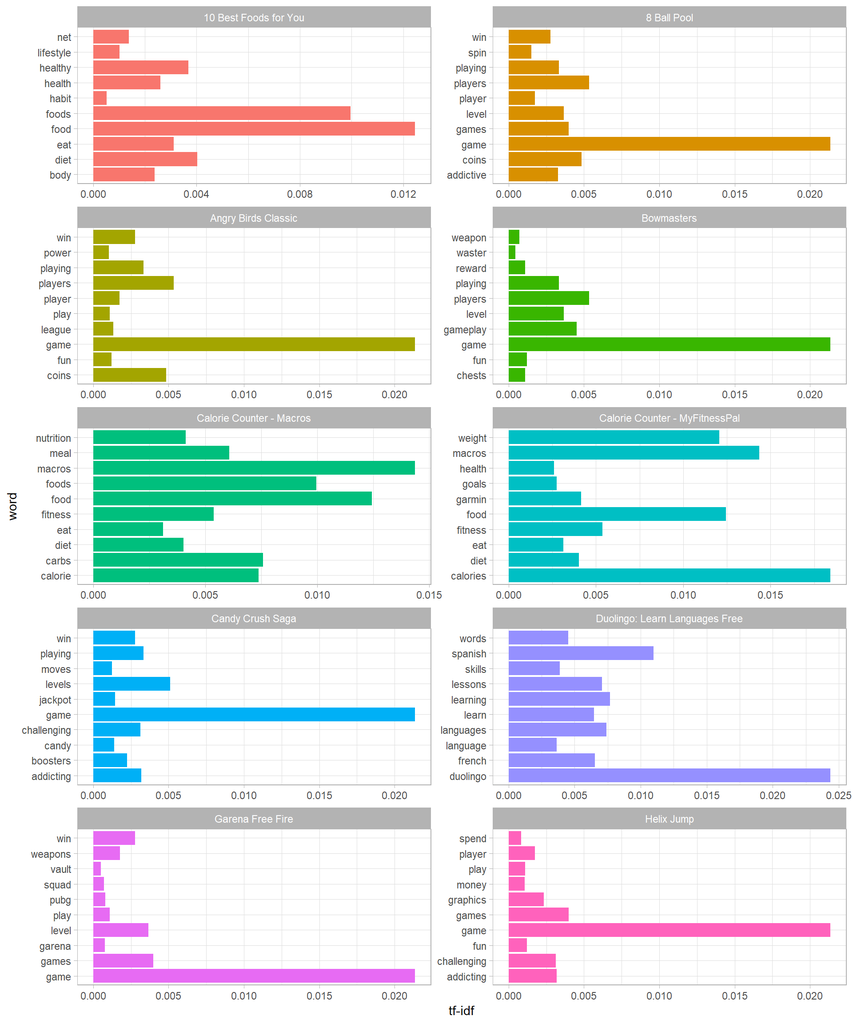

Ahora mostraremos los 10 terminos mas usados de las 5 reviews mas negativas de las apps con mas reviews, usaremos los resultados anteriores de AFINN como referencia

```r
top10_worst_reviews <- afinn %>%
  filter(App %in% top10_apps_reviews$App) %>%
  group_by(App) %>%
  arrange(score_sum) %>%
  filter(row_number() <= 5)

worst_words <- top10_worst_reviews %>%
  inner_join(tidy_reviews %>% mutate(App = NULL)) %>%
  inner_join(app_categories) %>%
  inner_join(tfidf_words, by=c("word", "Category")) %>%
  group_by(App) %>%
  distinct(word, .keep_all = TRUE) %>%
  ungroup() %>%
  arrange(App, desc(tf_idf)) %>%
  group_by(App) %>%
  filter(row_number() <= 10)
```

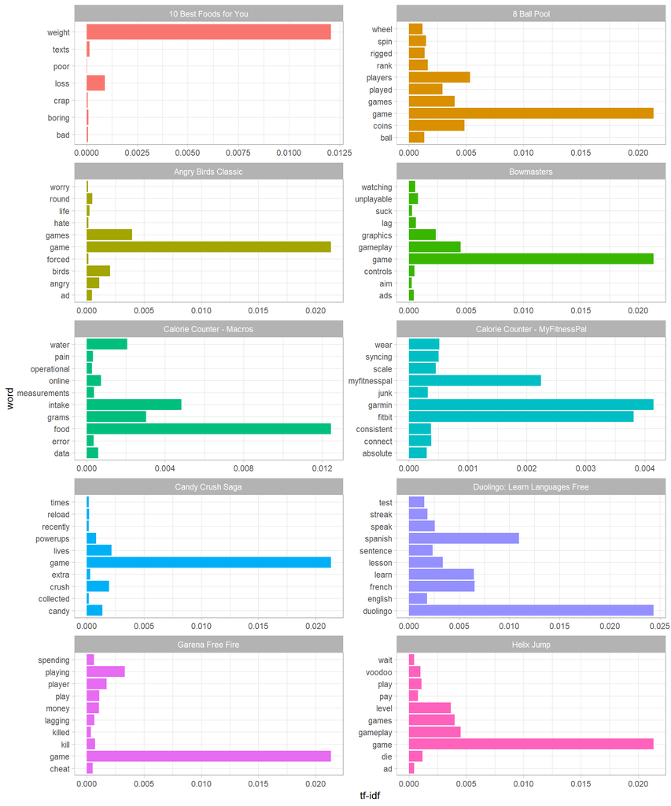